# Running R & TMB with GPU

Gavin Fay

June 24, 2016

@kaskr was interested in running TMB using an Nvidia GPU using nvblas. Herein brief comments on my experience installing and testing the performance.

My system - I am running Ubuntu 14.04, and I have an Nvidia Quadro K2000 graphics card.

## Installation

Brief summary of steps:

### 1. Install CUDA Toolkit

First ensure that you have a CUDA-capable GPU & download any necessary headers/etc.  
I followed the pre-installation instructions at:  
http://docs.nvidia.com/cuda/cuda-installation-guide-linux/index.html#pre-installation-actions  
(in my case I already had the right dependencies)

Download the CUDA Toolkit (current version 7.5) for your system from  
https://developer.nvidia.com/cuda-downloads

I used the local download installer (deb local). This can then be installed at command line,  
(e.g. by `sudo dpkg -i cuda-repo-<distro>_<version>_<architecture>.deb`).

Install CUDA by running  
1. `$ sudo dpkg -i cuda-repo-ubuntu1404-7-5-local_7.5-18_amd64.deb`  
2. `$ sudo apt-get update`  
3. `$ sudo apt-get install cuda`

(Section 3 of the installation guide details package manager installation for other linux systems)  
http://docs.nvidia.com/cuda/cuda-installation-guide-linux/index.html#package-manager-installation

The download link also provides instructions for other systems and installation options.

### 2. Modify `PATH` and `LD_LIBRARY_PATH` environment variables.

These are some post-installation instructions that need to be performed manually.  
(necessary details below, but more info at http://docs.nvidia.com/cuda/cuda-installation-guide-linux/index.html#post-installation-actions)

```
$ export PATH=/usr/local/cuda-7.5/bin:$PATH
$ export LD_LIBRARY_PATH=/usr/local/cuda-7.5/lib:$LD_LIBRARY_PATH
```

You can verify the installation by following some instructions at  
http://docs.nvidia.com/cuda/cuda-installation-guide-linux/index.html#recommended-post  
(these are recommended but not necessary to get working)

### 3. Create a config file `nvblas.conf`

This is necessary.  
There is an example on page 9 in the CUDA manual, that I copied to modify for my uses.  
(https://www.ecse.rpi.edu/~wrf/wiki/ParallelComputingSpring2014/nvidia/cuda6doc/pdf/NVBLAS_Library.pdf)

The only thing I had to change in here was the `NVBLAS_CPU_BLAS_LIB` variable, that tells it what blas to use for CPU.

Mine is:  
`NVBLAS_CPU_BLAS_LIB /usr/lib/libblas.so`

In addition, I had to create the below variable to point to the config file.

### 4. Set a environment variable `NVBLAS_CONFIG_FILE` that points to the config file.

`$ export NVBLAS_CONFIG_FILE=/path/to/config/file/nvblas.conf$NVBLAS_CONFIG_FILE`

For example, I put my `nvblas.conf` file in my home directory, and so my `NVBLAS_CONFIG_FILE` variable was created by:

```
$ export NVBLAS_CONFIG_FILE=/home/gavin/nvblas.conf$NVBLAS_CONFIG_FILE
```

### 5. Identify Location of libnvblas.so

(this is so you can load this when opening `R`)  
e.g. use `$ find /. -name "libnvblas.so"`

On my machine this was installed at: `/usr/local/cuda-7.5/lib64/libnvblas.so`

### 6. Open `R` loading the nvblas library, invoking use of the GPU.

Enter

```
$ LD_PRELOAD=/path/to/libnvblas/libnvblas.so R
```

So given the results of step 5, I run `R` using:

```
$ LD_PRELOAD=/usr/local/cuda-7.5/lib64/libnvblas.so R
```

This will start an instance of `R` allowing access to the GPU.

### 7. Run `R` commands as normal.

Note that the approach above just uses `R` commands and functions as normal, no special `R` functions written specifically for optimization on the GPU are used.

## Testing

To monitor GPU usage, in a separate shell I use `watch nvidia-smi`. In an additional shell I can monitor CPU usage using `top`.

### Simple tests

#### Matrix multiplication & Cholesky decomposition

I tried the following simple calculations on instances of `R` that either did or did not have the GPU loaded.

```
x <- diag(4e3)+1
system.time(x %*% x)
system.time(chol(x))
```

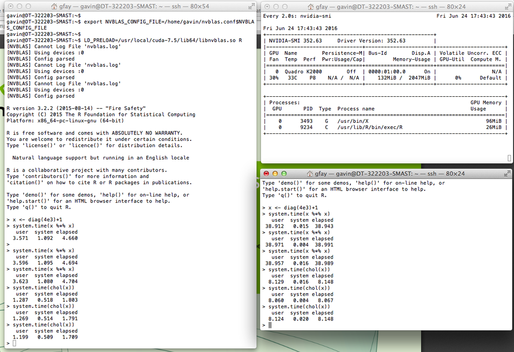

### Testing TMB

#### The `ar1_4D` example

Tested the `ar1_4D` example from the TMB examples folder.

```
system.time(source("ar1_4D.R"))
```

I ran the `ar1_4D` model with both n=8 and n=10.  
For n=8, improvement with GPU was minor.  
For n=10, with GPU was >2x faster than when run without GPU.

| scenario | n | user | system | elapsed |
| --- | --- | --- | --- | --- |
| with nvblas | 8 | 50.327 | 3.250 | 53.608 |
| normal R | 8 | 60.794 | 0.105 | 60.928 |
| with nvblas | 10 | 240.180 | 24.160 | 264.414 |
| normal R | 10 | 578.301 | 0.681 | 579.208 |